# lista2

## Część A

Wygeneruj sieć Erdős-Rényi o N = 100 i p = 0.05

```python
import networkx as nx
import random
N = 100
p = 0.05
seed_value = 42
random.seed(seed_value)
graph_er = nx.erdos_renyi_graph(N, p)
```

Wylistuj wszystkie wierzchołki i krawędzie,

```python
nodes = graph_er.nodes()
edges = graph_er.edges()

print("Wierzchołki:")
print(nodes)
print("Krawędzie:")
print(edges)
```

```
Wierzchołki:
[0, 1, 2, 3, 4, 5, 6, 7, 8, 9, 10, 11, 12, 13, 14, 15, 16, 17, 18, 19, 20, 21, 22, 23, 24, 25, 26, 27, 28, 29, 30, 31, 32, 33, 34, 35, 36, 37, 38, 39, 40, 41, 42, 43, 44, 45, 46, 47, 48, 49, 50, 51, 52, 53, 54, 55, 56, 57, 58, 59, 60, 61, 62, 63, 64, 65, 66, 67, 68, 69, 70, 71, 72, 73, 74, 75, 76, 7…
Krawędzie:
[(0, 2), (0, 10), (0, 13), (0, 20), (0, 42), (0, 68), (0, 90), (1, 3), (1, 27), (1, 29), (2, 75), (2, 96), (3, 7), (3, 34), (3, 52), (3, 78), (4, 9), (4, 30), (4, 42), (4, 96), (5, 14), (5, 22), (5, 25), (5, 39), (5, 49), (5, 64), (6, 17), (6, 26), (6, 65), (7, 20), (7, 52), (7, 64), (8, 62), (8, 71…
```

Oblicz stopień (degree) każdego węzła a następnie stwórz histogram stopni węzłów

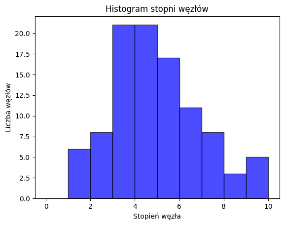

```python
degree_level = [graph_er.degree(node) for node in nodes]

import matplotlib.pyplot as plt

plt.hist(degree_level, bins=range(0,max(degree_level)+1), alpha=0.7, color='b', edgecolor='black')
plt.xlabel('Stopień węzła')
plt.ylabel('Liczba węzłów')
plt.title('Histogram stopni węzłów')
plt.show()
```

Ile jest komponentów (connected components) w grafie

```python
num_components = nx.number_connected_components(graph_er)
print("Liczba komponentów połączonych w grafie:", num_components)
```

```
Liczba komponentów połączonych w grafie: 1
```

Zwizualizuj graf w taki sposób, aby rozmiar węzłów odpowiadał mierze PageRank

[figure not shown]

```python
pagerank = nx.pagerank(graph_er)

plt.figure(figsize=(10, 8))
nx.draw_networkx(graph_er, pos=nx.spring_layout(graph_er), node_size=[v for v in pagerank.values()])
plt.title('Graf z węzłami o rozmiarze odpowiadającym PageRank')
plt.show()
```

## CZĘŚĆ B

Wygeneruj graf wedle modelu Barabási-Albert z N = 1000 i m0 = m = 3

```python
N = 1000
m = 3
graph_ba = nx.barabasi_albert_graph(N, m)
```

Zwizualizuj graf layoutem Kamada-Kawai

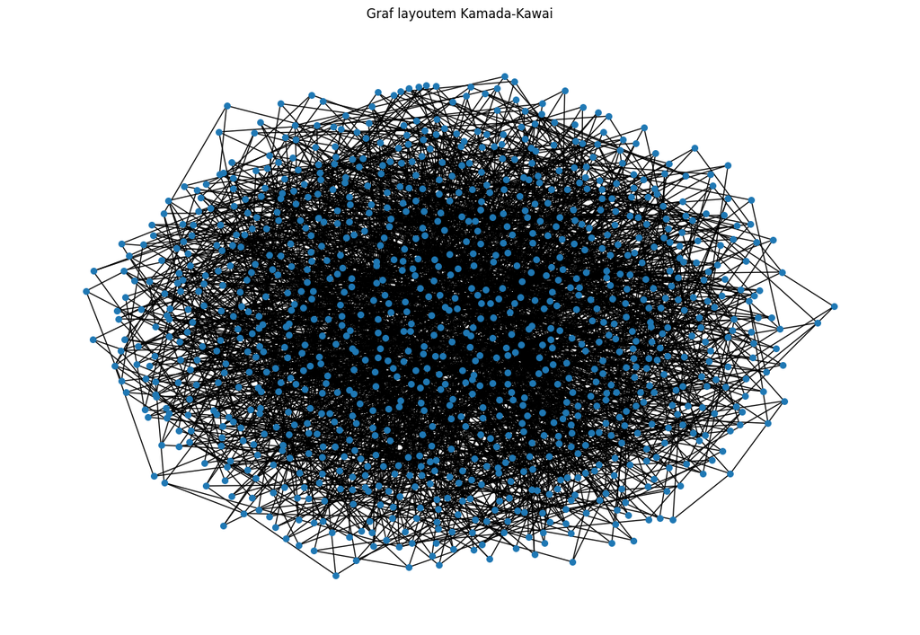

```python
plt.figure(figsize=(12, 8))
pos = nx.kamada_kawai_layout(graph_ba)
nx.draw(graph_ba, pos, with_labels=False, node_size=30)
plt.title('Graf layoutem Kamada-Kawai')
plt.show()
```

Znalezienie najbardziej centralnego węzła według miary pośrednictwa (betweenness):

```python
betweenness = nx.betweenness_centrality(graph_ba)
max_item = max(betweenness.items(), key=lambda x: x[1])
print("Najbardziej centralny węzeł według miary pośrednictwa:", max_item)
```

```
Najbardziej centralny węzeł według miary pośrednictwa: (0, 0.18780845085471823)
```

Jaka jest średnica grafu?

```python
diameter = nx.diameter(graph_ba)
print("Średnica grafu:", diameter)
```

```
Średnica grafu: 6
```

Jakie różnice widzisz pomiędzy grafem Barabási-Albert i Erdős-Rényi

Różnica polega w generowaniu: Graf Barabási-Alberta: że nowe węzły łączą się z istniejącymi węzłami z prawdopodobieństwem proporcjonalnym do stopnia tych istniejących węzłów (tzw. "skupisk").

Graf Erdős-Rényi: losowe dodawanie krawędzi między wierzchołkami z określonym prawdopodobieństwem - bez preferencji dla wierzchołków o większym stopniu, a każda para wierzchołków ma jednakowe szanse na połączenie.